# ExtraaLearn Project

## Do we need to prune the tree?

Our random forest modedl does not overfit. Hence, we do not need to prone it. However, its always a ML best practice to try different methods to improve our model, and we are going to do just that.

```python
#perform gridsearchCV

#set up the parameter grid
grid_search_par = {
    'n_estimators': [50, 100, 150, 200, 500],
    'max_features': ['auto', 'sqrt', 'log2'],
    'max_depth': [2,4,6,8,10],
    'criterion': ['gini', 'entropy']
}

#set up the estimator
RF_clf_gs = RandomForestClassifier(random_state =42)

#run the gridsearchCV for the estimator
grid_search_RF = GridSearchCV(RF_clf_gs, grid_search_par, cv =5)
#fit gridsearch
grid_search_RF.fit(X_,y_['status'])
print('The best hyperparameters are:', grid_search_RF.best_params_)
```

```
The best hyperparameters are: {'criterion': 'entropy', 'max_depth': 8, 'max_features': 'sqrt', 'n_estimators': 50}
```

```
train data
              precision    recall  f1-score   support

           0       0.88      0.93      0.91      2588
           1       0.81      0.71      0.76      1101

    accuracy                           0.87      3689
   macro avg       0.85      0.82      0.83      3689
weighted avg       0.86      0.87      0.86      3689
```

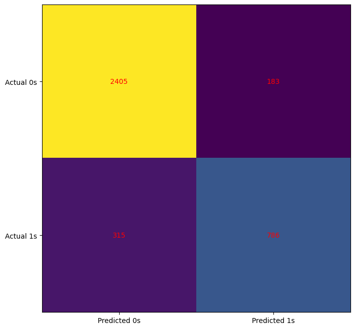

```
test data
              precision    recall  f1-score   support

           0       0.94      0.95      0.95       647
           1       0.88      0.86      0.87       276

    accuracy                           0.92       923
   macro avg       0.91      0.90      0.91       923
weighted avg       0.92      0.92      0.92       923
```

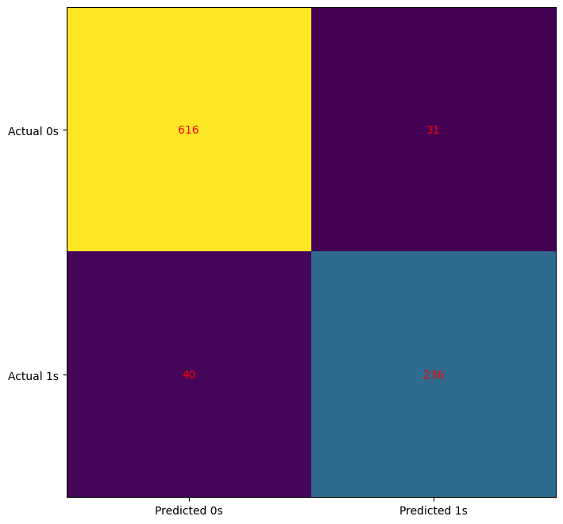

```python
#build a random forest model with the beat hyperparameters
RF_clf_hp = RandomForestClassifier(random_state= 42,
                                   criterion ='entropy',
                                   max_depth = 8,
                                   max_features = 'sqrt',
                                   n_estimators = 50)

#fit the model
RF_clf_hp.fit(X_, y_['status'])

#loop through the train and test data to get predictions and scores
for name, X_, y_ in get_X_y:
  value_RF_hp = RF_clf_hp.predict_proba(X_)
  #covert possible negative values to zero
  value_RF_hp[value_RF_hp <0] =0
  #add the probabilities to the dataset
  y_['status_proba_RF_hp'] = value_RF_hp[:,1]

  #get the actual predictions
  y_['status_pred_RF_hp'] =  y_['status_proba_RF_hp'] > 0.5

  #get the scores
  score = metric_score(y_true= y_['status'], y_pred= y_['status_pred_RF_hp'])
```

```python
#get the AUR_ROC score
for name, X_, y_ in get_X_y:
  score_ROC = metric_for_status(y_true=y_['status'], y_score=y_['status_proba_RF_hp'])
```

```
train     : 0.914
test      : 0.983
```

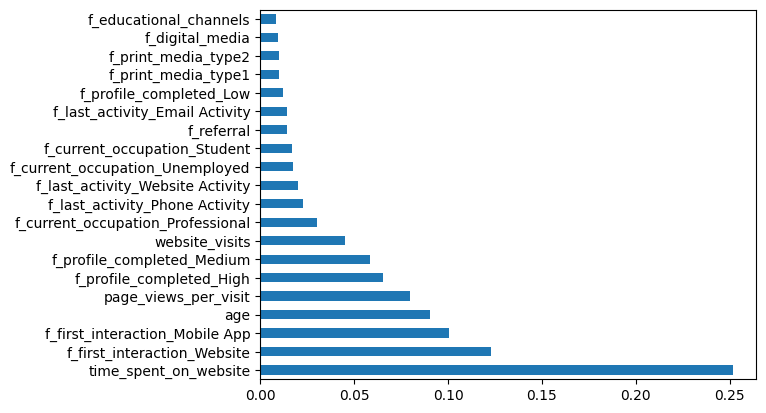

```python
#get the feature impostance
#feature importance
importance_RF_hp = pd.Series(RF_clf_hp.feature_importances_, index = X_train.columns.tolist()).sort_values(ascending= False)
importance_RF_hp.plot(kind ='barh')
```

```python
importance_RF_hp
```

|  | 0 |
| --- | --- |
| time_spent_on_website | 0.251526 |
| f_first_interaction_Website | 0.122687 |
| f_first_interaction_Mobile App | 0.100316 |
| age | 0.090449 |
| page_views_per_visit | 0.079562 |
| f_profile_completed_High | 0.065336 |
| f_profile_completed_Medium | 0.058530 |
| website_visits | 0.045402 |
| f_current_occupation_Professional | 0.030153 |
| f_last_activity_Phone Activity | 0.022821 |
| f_last_activity_Website Activity | 0.019948 |
| f_current_occupation_Unemployed | 0.017622 |
| f_current_occupation_Student | 0.016829 |
| f_referral | 0.014094 |
| f_last_activity_Email Activity | 0.014033 |
| f_profile_completed_Low | 0.012305 |
| f_print_media_type1 | 0.010146 |
| f_print_media_type2 | 0.010080 |
| f_digital_media | 0.009502 |
| f_educational_channels | 0.008657 |

**dtype:** float64

Unlike previous models. This models shows that all features have some importance. Time Spent on the website is the most significant predictor of conversion, and so on.

Now, we are going to try and run a model with features with important gater than 0.03

```python
importance_RF_hp = importance_RF_hp[importance_RF_hp > 0.03]
importance_RF_hp
```

|  | 0 |
| --- | --- |
| time_spent_on_website | 0.251526 |
| f_first_interaction_Website | 0.122687 |
| f_first_interaction_Mobile App | 0.100316 |
| age | 0.090449 |
| page_views_per_visit | 0.079562 |
| f_profile_completed_High | 0.065336 |
| f_profile_completed_Medium | 0.058530 |
| website_visits | 0.045402 |
| f_current_occupation_Professional | 0.030153 |

**dtype:** float64

```
train data
              precision    recall  f1-score   support

           0       0.87      0.89      0.88      2588
           1       0.73      0.70      0.71      1101

    accuracy                           0.83      3689
   macro avg       0.80      0.79      0.80      3689
weighted avg       0.83      0.83      0.83      3689
```

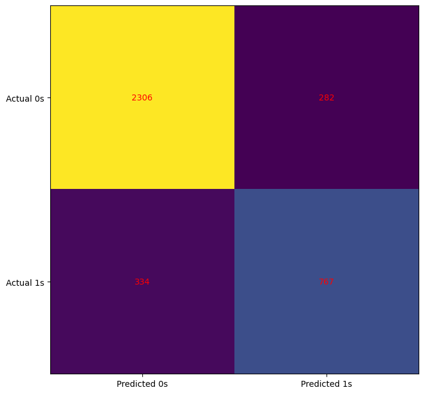

```
test data
              precision    recall  f1-score   support

           0       0.96      0.95      0.95       647
           1       0.89      0.89      0.89       276

    accuracy                           0.93       923
   macro avg       0.92      0.92      0.92       923
weighted avg       0.94      0.93      0.94       923
```

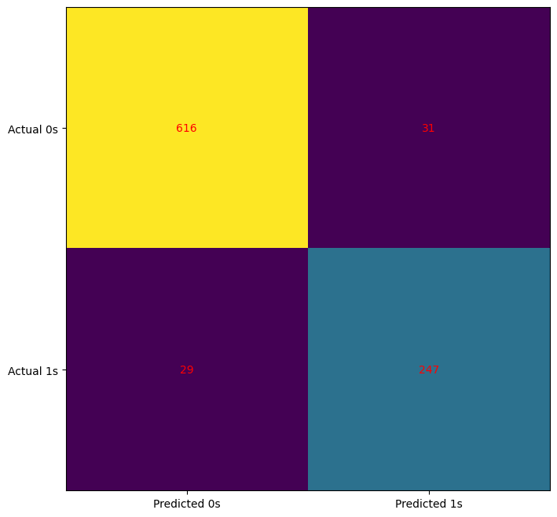

```python
#build a random forest model with the beat hyperparameters
RF_clf_hp_fi = RandomForestClassifier(random_state= 42,
                                   criterion ='entropy',
                                   max_depth = 8,
                                   max_features = 'sqrt',
                                   n_estimators = 50)

#fit the model
RF_clf_hp_fi.fit(X_[importance_RF_hp.index.tolist()], y_['status'])

#loop through the train and test data to get predictions and scores
for name, X_, y_ in get_X_y:
  value_RF_hp_fi = RF_clf_hp_fi.predict_proba(X_[importance_RF_hp.index.tolist()])
  #covert possible negative values to zero
  value_RF_hp_fi[value_RF_hp_fi <0] =0
  #add the probabilities to the dataset
  y_['status_proba_RF_hp_fi'] = value_RF_hp_fi[:,1]

  #get the actual predictions
  y_['status_pred_RF_hp_fi'] =  y_['status_proba_RF_hp_fi'] > 0.5

  #get the scores
  score = metric_score(y_true= y_['status'], y_pred= y_['status_pred_RF_hp_fi'])
```

```python
#get the AUR_ROC score
for name, X_, y_ in get_X_y:
  score_ROC = metric_for_status(y_true=y_['status'], y_score=y_['status_proba_RF_hp_fi'])
```

```
train     : 0.894
test      : 0.988
```

## Actionable Insights and Recommendations

After a throrough analysis of the results of our models, and the informaton learned through this project. Here are some recommendations and insights for ExtraaLearn:

- Website Since the time spent on the website is the stronger predictor for conversion, followed by the first interaction through the website. We recommend pivoting on it, investing in content that will retain leads on the website through countless offers, discounts, and benefits; driving most, if not all, of the traffic to the website; improving the content and design of the website; and making it more user-friendly. Since page_views_per_visit is also one of the strongest predictors, ExtraaLearn should encourage leads to visit the website more frequently and navigate through multiple pages. Include some activities that can keep them engaging with the website, such as personalized content recommendations, free educational material, free giveaway contests based on completing certain tasks on the website, etc.It is very important to include many testimonials and feedback from other customers on a very visible and dedicated part of the website. Social proof usually stays one click away from converting leads into paying customers.
- Mobile APP The mobile app also has a huge influence on converting leads to paying customers. Hence, we recommend using it as a second option for driving traffic (make it clear on the website that we also have an app, so potential customers may have options) and offer options to switch through both platforms effortlessly. Alternatively, we would recommend making the app content and design similar to the website or even better. Perhaps the website converts more because it has better content and design.
- Focusing more on the right age demographics Since older professionals looking for career advancements are the most likely to become customers over other demographics. We suggest creating courses that target them and that address current industry needs and technologies such as ML and AI, data science, AI integration, and so on.
- Profile completion Encourage the leads to complete their profiles through constant reminders and incentives.
- Even though other features have a lower impact on the status of the lead. We still recommend not ignoring them completely but focusing more on the top 9 features, such as time spent on the website, first interaction via website, first interaction via mobile app, age, page views per visit, profile completion (high), profile completion (medium), page visits, and current occupation. These are the metrics the company should allocate the most time and resources to. After making sure that those metrics have been properly taken care of, the company should enhance other metrics, such as referrals. This metric can play a huge role in bringing in customers; word of mouth is one of the best marketing tools we can use.